# RMarkdown Assignment -> BDA PDA Edition

Nick Kolarik

2/17/2020

## Introduce your dissertation or thesis

The changing climate affects timing of water resource availability and requires land managers to adopt adaptation strategies accordingly. In arid and semi-arid regions of the American West, variability in precipitation and snowpack and rising temperatures limit access to water during dry summer months. Low-tech process-based stream restoration initiatives (PBR) have become widely popular in conservation efforts due to low cost and ease of construction. Previous analyses show that these structures are effective for expanding suitable aquatic and terrestrial wildlife habitats, but a comprehensive analysis of low-tech restoration project outcomes has not been conducted. In this analysis we ask: what are the local and landscape level impacts of these interventions with respect to influencing the total area and variability of surface water and mesic areas? Using remotely sensed satellite imagery, we will quantify landscape-level effects of low-tech stream restoration initiatives and show differences in local-level success of low-tech restoration projects in terms of increasing surface water and wet meadow extents.. The results of this analysis can help to understand conservation dynamics in a heterogenous social-scape where human agency and external factors play a role in efficacy and project outcomes.

## Study Area

The overarching goal of this proposal is to develop a way to monitor PBR activities in an efficient, cost-effective manner while also considering and understanding variation of context. Our study region, the High Divide is ideal for exploration due to varying land uses and ubiquity of need for adaptations to increase resilience to climatic uncertainty. Due to varying social and ecological contexts and perceptions, the multifaceted nature of the landscape mosaic provides opportunities for investigation into PBR successes, failures, and best practices at reach and watershed scales.

```r
library(rgdal)
library(sf)
```

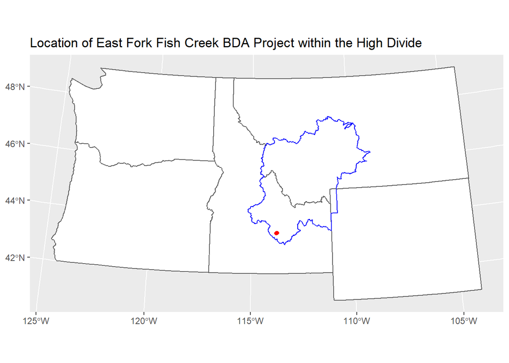

```r
setwd("C:/Users/nicho/BSU/rgeo/HES598/MarkdownAssignment_NEK")

## importing .shp for states and high divide
states <- "./data_nek/tl_2019_us_state.shp"
hd <- "./data_nek/hd_boundary.shp"

## returns an sf df
states.shape <- read_sf(states)
hd.shape <- read_sf(hd)

pnw <- c("WA", "OR", "MT", "ID", "WY")#, "NV", "UT")

## subsetting by states in the region -> there has to be a better way to do this!!!
sbst <- filter(states.shape, STUSPS == "WA" | STUSPS == "OR"|STUSPS =="MT"|STUSPS =="ID"|STUSPS =="WY")#|STUSPS =="NV"|STUSPS =="UT")

## defining projectsion of interest -> 'borrowed' from in class example
idaho.cent <- "+proj=tmerc +lat_1=41.66666666666666 +lon_0=-114 +k=0.9999473679999999 +x_0=500000.0001016001 +y_0=0 +ellps=GRS80 +datum=NAD83 +to_meter=0.3048006096012192 +no_defs "

## reproject
sbst.proj <- st_transform(sbst, st_crs(idaho.cent))
hd.proj <- st_transform(hd.shape, st_crs(idaho.cent))

### plot and specify attribute to display rather than multiples
#plot(sbst.reproj['STUSPS'], main = "High Divide and Vicinity")
### for some reason, add= T not working here
#plot(hd.reproj['acres'] , main = "High Divide and Vicinity", add= TRUE, col = 'red')

## East fork fish creek PBR structures
effc <- read.csv('./data_nek/Efork_fish_crk.csv')
#str(effc)

## convert to sf object
effc.sf <- st_as_sf(effc, coords = c("Long", "Lat"), crs = "+init=epsg:4269")
## project it
effc.proj <- st_transform(effc.sf, st_crs(idaho.cent))
## write it to a shapefile
#st_write(effc.proj, "./data_nek/eforkfish.shp", driver = "ESRI Shapefile")

## ggplot option works great, though distinctly ggplot appearance
ggplot() +
  geom_sf(data = sbst.proj, fill = 'white')+
  geom_sf(data = hd.proj, fill = NA , color = 'blue')+
  geom_sf(data = effc.proj, color = 'red')+
  ggtitle("Location of East Fork Fish Creek BDA Project within the High Divide")
```

```r
  #coord_sf()
```

## Map an attribute of your data

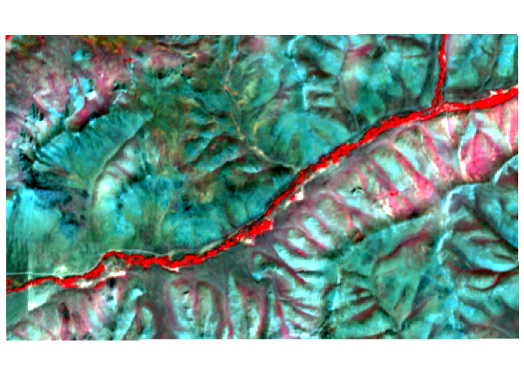

```r
## Plotting a false color composite from sentinel2 data
## Plotting structures at the east fork fish creek project on an NDVI image
library(raster)
## bring in sentinel2 data as a raster stack
sent2 <- stack("./data_nek/S2_2019.tif")
## projection returns a brick!
sent2.proj <- projectRaster(sent2, crs = idaho.cent)

## False color composite (NIR, R, G)
## plot -> sentinel data are scaled by 1000, correct for that so vals are 0:255 and apply a proper stretch
plotRGB(sent2.proj/1000, r = 1, g = 2, b = 3, stretch = "lin", main = "False color composite of East Fork Fish Creek")
```

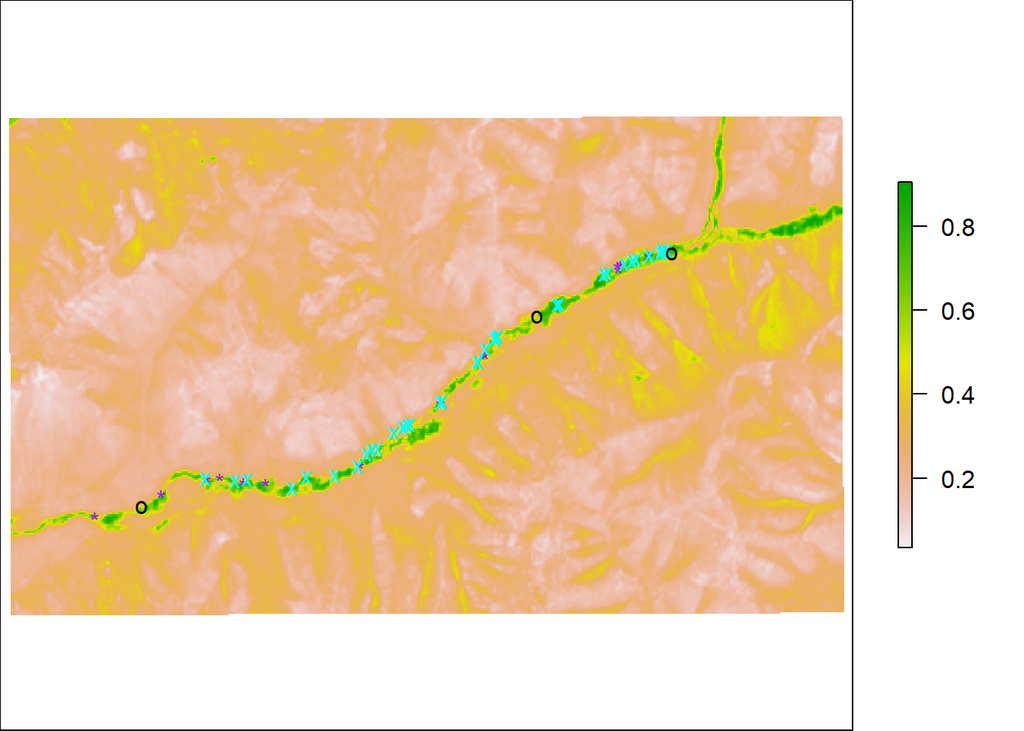

```r
## NDVI
ndvi <- raster("./data_nek/NDVI_2019.tif")
ndvi.proj <- projectRaster(ndvi, crs = idaho.cent )

## Base plotting and adding the locations of PBR structures
plot(ndvi.proj)
## adding PBR structures and changing symbology based on attribute (structure type) -> these colors are awful AND the title is absent
plot(effc.proj, col = c('black', 'purple', 'cyan')[effc.proj$Type], pch = c("o", "*", "x")[effc.proj$Type], add = T, main = "Dry Season NDVI of East Fork Fish Creek and PBR locations")
## legend is absent...
legend(0, legend = c("Beaver dam analog (BDA)", "Pole assisted log strucutre (PALS)", "Bank assisted log jam (BALJ)" ), col =  c('black', 'purple', 'cyan'), pch = c("o", "*", "x") )
```

## Plot your data a different way

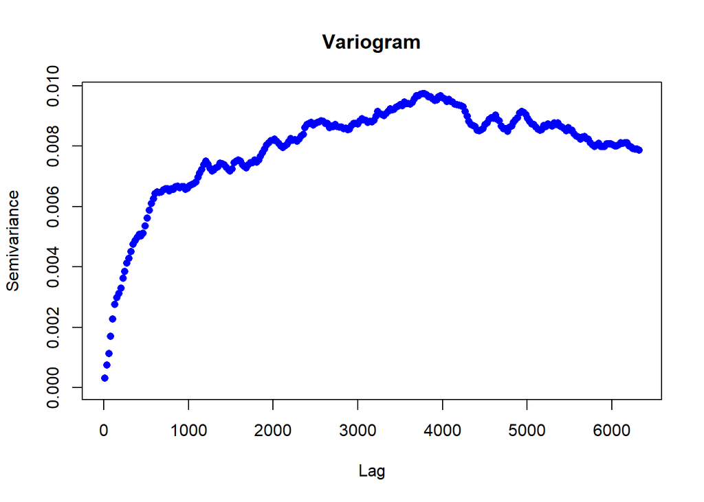

```r
## Create a semivariogram for NDVI as it relates to PBR structures (takes a while)
library(usdm)
library(gstat)

## use extract to get cell numbers for pbr locations to measure semivariance
pbr.vals <- extract(ndvi.proj, effc.proj, cellnumbers = T)
#pbr_cells <- cellFromXY(ndvi.proj, effc.proj)

pbr.df <- as.data.frame(pbr.vals)


## variogram
variog <- Variogram(ndvi.proj)#, cells = pbr_vals[,1])
plot(variog)##takes a while -> need to figure how to specify pbr structures for monitoring
```

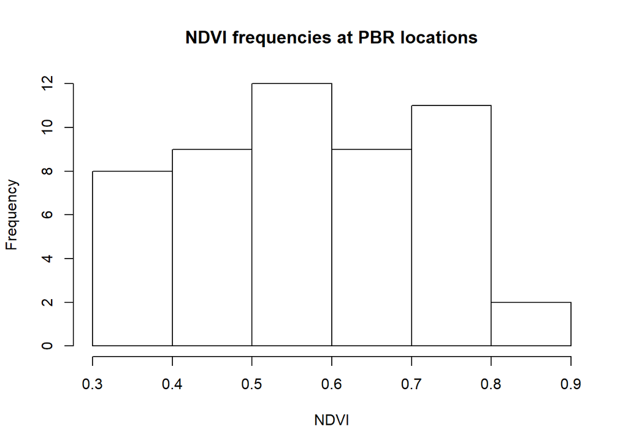

```r
## maybe not what i want anyway, variance will be low along the riparian zone, need a measure perpendicular to riparian zone

## conversion to df
ndvi.df <- as.data.frame(ndvi.proj, na.rm = T)
### BROKEN
#pbr.var <- gstat::variogram(NDVI_2019~1, locations = xyFromCell(ndvi, cell = pbr.vals[,1]), data = ndvi.df)

## complete the assignment
hist(pbr.df$NDVI_2019, main = "NDVI frequencies at PBR locations", xlab = "NDVI")
```

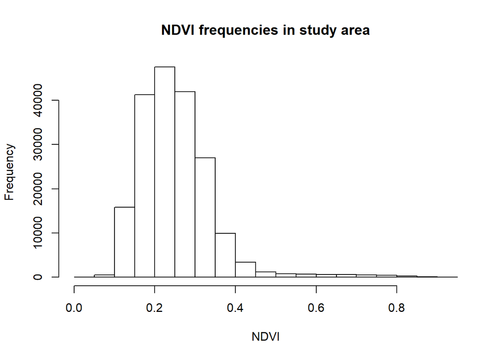

```r
hist(ndvi.df$NDVI_2019, main = "NDVI frequencies in study area", xlab = "NDVI")
```

## What did you learn?

To measure the influence of each structure, I had the idea that a semivariogram would describe the distance at which the PBR structure has no influence on vegetation. In this case, I thought the range of correlated NDVI values could describe influence, as this index has been used in previous studies with Landsat data (Silverman et al., 2019), though not using spatial variance as a metric. However, NDVI values are highly correlated along the riparian zone, so I would need to only measure variance in productivity values in a perpendicular direction from the creek. It is clear that productivity is greater in the riparian zone, but definitely useful to see the plots rather than simple histograms.